# A2 224X_R Notebook

Creating subset of data

```r
recsV4 <- recs2015_public_v3[, c("DIVISION", "UATYP10","TOTALBTU" , "NHSLDMEM" , "MONEYPY" , "HDD65", "NUMFRIG" , "NUMBERAC" , "WASHLOAD", "LGTINLED", "AIRCOND", "HEATHOME", "CDD65")]
```

Q: List your chosen drivers with a brief description of why you selected each. You are asked to give them in order of your guess of most correlated (Driver 1) to least correlated (Driver 5) with TOTALBTU. Please commit to responses to this question before moving on; you may end up changing your chosen drivers, but the point of this question is to test your intuition.

Driver 1:NUMBERAC (This is the number of AC units, I think it is important since HAVC systems account for the greatest percentage of energy consumption in buildings, followed by lighting and plugloads) Driver 2: WASHLOAD (This is the frequency for using the washing machine per week. I consider the washing machine to be one of the appliances in a home that uses the most of energy. Plus, it is within the plugloads category that I consider important) Driver 3:AIRCOND (This is whether a home has AC or not. I consider this to be an important driver of energy consumption given my explanation for driver 1, however I considered 1 to be more important given the level of granularity of the data. Drivers 3 & 4 only have 2 levels) Driver 4:HEATHOME (Same as Driver 3) Driver 5:LGTINLED (This is the percentage of the lights that are LED. Given the contribution of lighting to the total energy consumption in buildings ) Driver 6: (additional driver) (Cooling Degree days at 65F. I just wanted to try it, given HDD65 is a key variable used to model energy consumption in buildings)

All the measures above where chosen taking into consideration the feasibililty of retrofits in existing buildings as well as the possibility of implementing a new policy to regulate the variables that are found to contribute the most to energy consumption in our model

Cleaning data

```r
# filtering
recsV5 <- filter(recsV4,DIVISION == 10 & UATYP10 == "U" )
# Deleting -2
## See how can I delete from more than one column
recsV6 <-recsV5[ grep("-2", recsV5$NUMBERAC, invert = TRUE),]
recsV7 <-recsV6[ grep("-2", recsV6$WASHLOAD, invert = TRUE),]
```

Changing categoricals MONEYPY and LGTINLED to numerical variables (usd and percentages)

For MONEYPY 1 = 10000 2 = 30000 3 = 50000 4 = 70000 5 = 90000 6 = 110000 7 = 130000 8 = 150000

For LGTINLED

1 = 100 2 = 75 3 = 50 4 = 25 0 = 0

```r
#foo <- mapvalues(foo, from=c("AA", "AC", "AG"), to=c("0101", "0102", "0103"))
# vectorToUpdate is dataframe$vectorname)
# (dataframe$vectorname)<- mapvalues (dataframe$vectorname, from = c ("oldValue1", "oldValue2", etc), to = c ("newValue1", "newValue2", etc))
#recsV7$LGTINLED <- mapvalues(recsV7$LGTINLED, from = c("1", "2", "3", "4", "0"), to = c("100", "75", "50", "25", "0" ))
#recsV7$MONEYPY <- mapvalues(recsV7$MONEYPY, from = c("1", "2", "3", "4", "5", "6", "7", "8"), to = c("10000", "30000", "50000", "70000", "90000", "110000", "130000", "150000" ))
recsV7$MONEYPY <- replace(recsV7$MONEYPY, recsV7$MONEYPY == 1, 10000)
recsV7$MONEYPY <- replace(recsV7$MONEYPY, recsV7$MONEYPY == 2, 30000)
recsV7$MONEYPY <- replace(recsV7$MONEYPY, recsV7$MONEYPY == 3, 50000)
recsV7$MONEYPY <- replace(recsV7$MONEYPY, recsV7$MONEYPY == 4, 70000)
recsV7$MONEYPY <- replace(recsV7$MONEYPY, recsV7$MONEYPY == 5, 90000)
recsV7$MONEYPY <- replace(recsV7$MONEYPY, recsV7$MONEYPY == 6, 110000)
recsV7$MONEYPY <- replace(recsV7$MONEYPY, recsV7$MONEYPY == 7, 130000)
recsV7$MONEYPY <- replace(recsV7$MONEYPY, recsV7$MONEYPY == 8, 150000)
recsV7$LGTINLED <- replace(recsV7$LGTINLED, recsV7$LGTINLED == 1, 100)
recsV7$LGTINLED <- replace(recsV7$LGTINLED, recsV7$LGTINLED == 2, 75)
recsV7$LGTINLED <- replace(recsV7$LGTINLED, recsV7$LGTINLED == 3, 50)
recsV7$LGTINLED <- replace(recsV7$LGTINLED, recsV7$LGTINLED == 4, 25)
```

Correlation matrix

```r
forCorrMatRecs <- recsV7[,c(3:13)]
corrMatrRecs = cor(forCorrMatRecs)
```

```
the standard deviation is zero
```

```r
round (corrMatrRecs,2)
```

```
         TOTALBTU NHSLDMEM MONEYPY HDD65 NUMFRIG NUMBERAC WASHLOAD LGTINLED AIRCOND HEATHOME CDD65
TOTALBTU     1.00     0.38    0.24  0.22    0.30     0.07     0.34     0.11      NA     0.41 -0.24
NHSLDMEM     0.38     1.00    0.19 -0.10    0.18     0.24     0.44    -0.12      NA     0.19  0.01
MONEYPY      0.24     0.19    1.00 -0.33    0.25     0.13     0.03     0.15      NA     0.11  0.13
HDD65        0.22    -0.10   -0.33  1.00   -0.09    -0.02     0.18    -0.11      NA     0.42 -0.67
NUMFRIG      0.30     0.18    0.25 -0.09    1.00     0.11     0.07     0.08      NA     0.16  0.07
NUMBERAC     0.07     0.24    0.13 -0.02    0.11     1.00     0.08     0.10      NA     0.03  0.12
WASHLOAD     0.34     0.44    0.03  0.18    0.07     0.08     1.00     0.01      NA     0.25 -0.15
LGTINLED     0.11    -0.12    0.15 -0.11    0.08     0.10     0.01     1.00      NA    -0.01 -0.10
AIRCOND        NA       NA      NA    NA      NA       NA       NA       NA       1       NA    NA
HEATHOME     0.41     0.19    0.11  0.42    0.16     0.03     0.25    -0.01      NA     1.00 -0.58
CDD65       -0.24     0.01    0.13 -0.67    0.07     0.12    -0.15    -0.10      NA    -0.58  1.00
```

Q: Interpret the results of your correlation analysis. Identify and discuss the 2-3 strongest and weakest correlated pairs that include the outcome-of-interest, TOTALBTU, specifically any surprises.

Strong 1: TOTALBTU & HEATHOME (0.41) (this potentially means that the most amount of energy comes from heating) Strong 2: TOTALBTU & NHSLDMEM (0.38) (it makes sense that the more people in a home, the higher the energy consumption) Strong 3: TOTALBTU & WASHLOAD (0.34) (this seems somehow correlated with the number of people in the house, meaning the use of washing machine is more frequent)

Weak 1: TOTALBTU & CDD65 (-0.24) (Negative correlation, which not that intuitive, statistically it means that as cooling increases, total btus decreases) Weak 2:TOTALBTU & NUMBERAC (0.07)( This is close to 0, which means no correlation, which means that number of AC units has almost no effect on totalBTUs Weak 3: TOTALBTU & LGTINLED (0.11) (this means that LEDs are not as impactful to energy consumption )

Then identify and discuss the 2-3 strongest correlated pairs that don’t include the outcome-of-interest (like MONEYPY vs. HDD65), and how these correlations may affect our regression analysis.

Plot the strongest pair

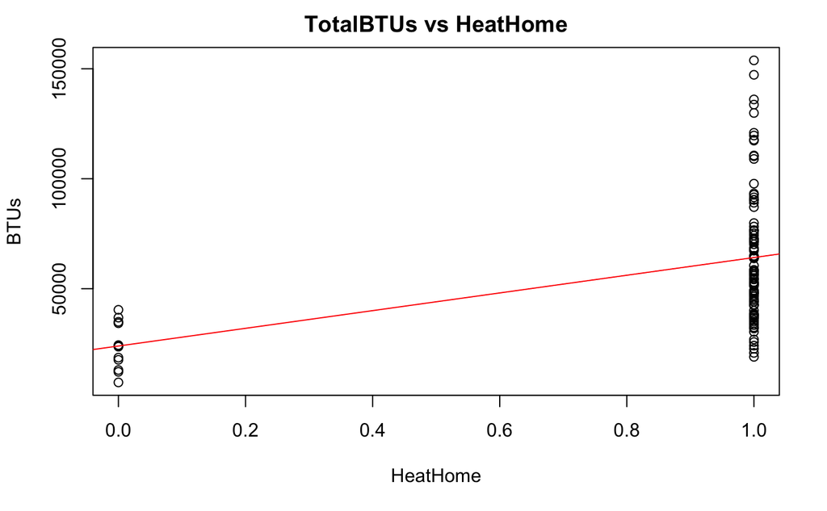

```r
plot (recsV7$HEATHOME, recsV7$TOTALBTU, main = "TotalBTUs vs HeatHome", xlab= "HeatHome", ylab = "BTUs")
abline(lm(TOTALBTU ~ HEATHOME), col=2)
```

Single Variable Linear Fit for HeatHome

```r
lm.fitHeat = lm(TOTALBTU ~ HEATHOME, data=recsV7)
lm.fitHeat
```

```
Call:
lm(formula = TOTALBTU ~ HEATHOME, data = recsV7)

Coefficients:
(Intercept)     HEATHOME
      23940        40275
```

```r
summary (lm.fitHeat)
```

```
Call:
lm(formula = TOTALBTU ~ HEATHOME, data = recsV7)

Residuals:
   Min     1Q Median     3Q    Max
-45209 -19025  -6285  11520  89608

Coefficients:
            Estimate Std. Error t value Pr(>|t|)
(Intercept)    23940       8222   2.912  0.00439 **
HEATHOME       40275       8726   4.616 1.11e-05 ***
---
Signif. codes:  0 ‘***’ 0.001 ‘**’ 0.01 ‘*’ 0.05 ‘.’ 0.1 ‘ ’ 1

Residual standard error: 28480 on 105 degrees of freedom
Multiple R-squared:  0.1687,    Adjusted R-squared:  0.1608
F-statistic:  21.3 on 1 and 105 DF,  p-value: 1.113e-05
```

```r
#plot (lm.fitHeat)
```

Outliers analysis

```r
# Outlier analysis
# Separating data in two clusters based on whether they have heating systems or not
highbtu <- filter(recsV7, HEATHOME == 1)
min(highbtu$TOTALBTU)
```

```
[1] 19006.8
```

```r
max(highbtu$TOTALBTU)
```

```
[1] 153823.2
```

```r
summary(highbtu)
```

```
    DIVISION    UATYP10             TOTALBTU         NHSLDMEM        MONEYPY           HDD65
 Min.   :10   Length:95          Min.   : 19007   Min.   :1.000   Min.   : 10000   Min.   : 623
 1st Qu.:10   Class :character   1st Qu.: 43411   1st Qu.:2.000   1st Qu.: 30000   1st Qu.:1938
 Median :10   Mode  :character   Median : 56792   Median :3.000   Median : 70000   Median :3315
 Mean   :10                      Mean   : 64215   Mean   :3.179   Mean   : 70842   Mean   :2945
 3rd Qu.:10                      3rd Qu.: 76358   3rd Qu.:4.000   3rd Qu.:110000   3rd Qu.:4030
 Max.   :10                      Max.   :153823   Max.   :8.000   Max.   :150000   Max.   :5405
    NUMFRIG         NUMBERAC        WASHLOAD         LGTINLED     AIRCOND     HEATHOME     CDD65
 Min.   :0.000   Min.   :1.000   Min.   : 1.000   Min.   : 0   Min.   :1   Min.   :1   Min.   : 219.0
 1st Qu.:1.000   1st Qu.:1.000   1st Qu.: 3.000   1st Qu.: 0   1st Qu.:1   1st Qu.:1   1st Qu.: 516.5
 Median :1.000   Median :1.000   Median : 4.000   Median : 0   Median :1   Median :1   Median : 728.0
 Mean   :1.421   Mean   :1.579   Mean   : 4.758   Mean   :10   Mean   :1   Mean   :1   Mean   :1022.5
 3rd Qu.:2.000   3rd Qu.:2.000   3rd Qu.: 6.000   3rd Qu.:25   3rd Qu.:1   3rd Qu.:1   3rd Qu.:1553.5
 Max.   :5.000   Max.   :4.000   Max.   :15.000   Max.   :75   Max.   :1   Max.   :1   Max.   :2987.0
```

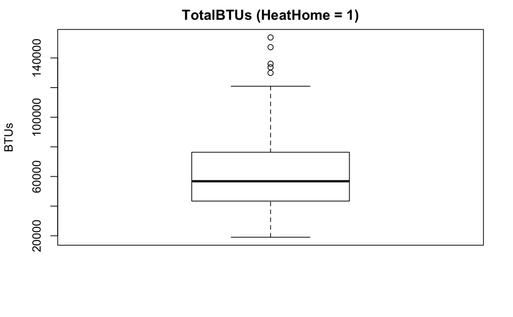

```r
boxplot(highbtu$TOTALBTU, main = "TotalBTUs (HeatHome = 1)", ylab = "BTUs")
```

```r
minbtu <- filter (recsV7, HEATHOME == 0)
min (minbtu$TOTALBTU)
```

```
[1] 7381.821
```

```r
max(minbtu$TOTALBTU)
```

```
[1] 40401.88
```

```r
summary(minbtu)
```

```
    DIVISION    UATYP10             TOTALBTU        NHSLDMEM        MONEYPY           HDD65
 Min.   :10   Length:12          Min.   : 7382   Min.   :1.000   Min.   : 10000   Min.   :   0.00
 1st Qu.:10   Class :character   1st Qu.:16498   1st Qu.:1.000   1st Qu.: 25000   1st Qu.:   2.25
 Median :10   Mode  :character   Median :23790   Median :2.000   Median : 40000   Median : 756.00
 Mean   :10                      Mean   :23940   Mean   :2.083   Mean   : 55000   Mean   : 857.83
 3rd Qu.:10                      3rd Qu.:34453   3rd Qu.:2.000   3rd Qu.: 60000   3rd Qu.:1291.50
 Max.   :10                      Max.   :40402   Max.   :7.000   Max.   :150000   Max.   :2251.00
    NUMFRIG         NUMBERAC      WASHLOAD        LGTINLED        AIRCOND     HEATHOME     CDD65
 Min.   :1.000   Min.   :1.0   Min.   :0.000   Min.   : 0.00   Min.   :1   Min.   :0   Min.   : 263
 1st Qu.:1.000   1st Qu.:1.0   1st Qu.:1.000   1st Qu.: 0.00   1st Qu.:1   1st Qu.:0   1st Qu.:1735
 Median :1.000   Median :1.0   Median :1.000   Median : 0.00   Median :1   Median :0   Median :2439
 Mean   :1.083   Mean   :1.5   Mean   :2.667   Mean   :10.42   Mean   :1   Mean   :0   Mean   :2992
 3rd Qu.:1.000   3rd Qu.:2.0   3rd Qu.:4.000   3rd Qu.:25.00   3rd Qu.:1   3rd Qu.:0   3rd Qu.:4997
 Max.   :2.000   Max.   :3.0   Max.   :8.000   Max.   :50.00   Max.   :1   Max.   :0   Max.   :5859
```

```r
#Outliers (Q3 + 1.5 (Q3-Q1))
highUp <- 75358 + 1.5 * (76358-43411)
outliers <- filter(highbtu, TOTALBTU > highUp)
outliers
```

| DIVISION | UATYP10 | TOTALBTU | NHSLDMEM | MONEYPY | HDD65 | NUMFRIG | NUMBERAC | WASHLOAD | LGTINLED | AIRCOND | HEATHOME | CDD65 |
| --- | --- | --- | --- | --- | --- | --- | --- | --- | --- | --- | --- | --- |
| 10 | U | 153823.2 | 3 | 90000 | 4106 | 1 | 2 | 6 | 25 | 1 | 1 | 550 |
| 10 | U | 147254.0 | 5 | 90000 | 5051 | 1 | 3 | 5 | 0 | 1 | 1 | 953 |
| 10 | U | 133699.3 | 4 | 150000 | 1890 | 2 | 2 | 4 | 0 | 1 | 1 | 819 |
| 10 | U | 136050.1 | 2 | 70000 | 4113 | 1 | 1 | 7 | 25 | 1 | 1 | 546 |
| 10 | U | 129898.6 | 4 | 90000 | 4051 | 2 | 2 | 6 | 50 | 1 | 1 | 441 |

```r
highMon <- 110000 + 1.5*(110000-30000)
highMon
```

```
[1] 230000
```

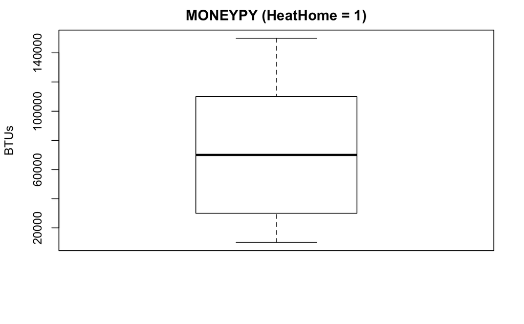

```r
boxplot(highbtu$MONEYPY, main = "MONEYPY (HeatHome = 1)", ylab = "BTUs")
```

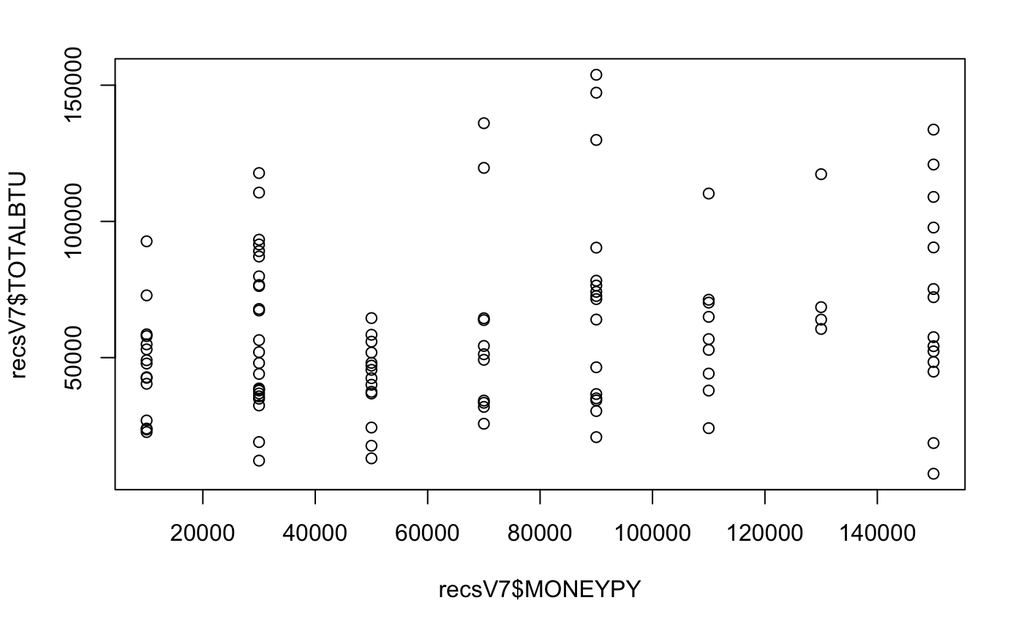

```r
plot(recsV7$MONEYPY, recsV7$TOTALBTU)
```

```r
#Fitting a liner model to understand the drivers of the outliers
lm.fitHigh = lm(TOTALBTU ~ NHSLDMEM + MONEYPY + HDD65 + NUMFRIG + NUMBERAC + WASHLOAD + LGTINLED + HEATHOME + AIRCOND + CDD65, data=highbtu)
lm.fitHigh
```

```
Call:
lm(formula = TOTALBTU ~ NHSLDMEM + MONEYPY + HDD65 + NUMFRIG +
    NUMBERAC + WASHLOAD + LGTINLED + HEATHOME + AIRCOND + CDD65,
    data = highbtu)

Coefficients:
(Intercept)     NHSLDMEM      MONEYPY        HDD65      NUMFRIG     NUMBERAC     WASHLOAD     LGTINLED
 -2324.2157    5059.1651       0.1475       6.6754    8381.5299   -2774.5050    1098.7643     266.5325
   HEATHOME      AIRCOND        CDD65
         NA           NA       4.8186
```

```r
summary (lm.fitHigh)
```

```
Call:
lm(formula = TOTALBTU ~ NHSLDMEM + MONEYPY + HDD65 + NUMFRIG +
    NUMBERAC + WASHLOAD + LGTINLED + HEATHOME + AIRCOND + CDD65,
    data = highbtu)

Residuals:
   Min     1Q Median     3Q    Max
-51872 -19021  -5353  14821  81551

Coefficients: (2 not defined because of singularities)
              Estimate Std. Error t value Pr(>|t|)
(Intercept) -2.324e+03  1.576e+04  -0.148   0.8831
NHSLDMEM     5.059e+03  1.922e+03   2.632   0.0100 *
MONEYPY      1.475e-01  6.979e-02   2.113   0.0375 *
HDD65        6.675e+00  2.720e+00   2.454   0.0161 *
NUMFRIG      8.382e+03  4.071e+03   2.059   0.0425 *
NUMBERAC    -2.775e+03  4.076e+03  -0.681   0.4979
WASHLOAD     1.099e+03  1.250e+03   0.879   0.3817
LGTINLED     2.665e+02  1.944e+02   1.371   0.1740
HEATHOME            NA         NA      NA       NA
AIRCOND             NA         NA      NA       NA
CDD65        4.819e+00  5.650e+00   0.853   0.3961
---
Signif. codes:  0 ‘***’ 0.001 ‘**’ 0.01 ‘*’ 0.05 ‘.’ 0.1 ‘ ’ 1

Residual standard error: 26650 on 86 degrees of freedom
Multiple R-squared:  0.2719,    Adjusted R-squared:  0.2042
F-statistic: 4.015 on 8 and 86 DF,  p-value: 0.0004357
```

Q: Discuss the results of your scatter plot and the goodness of fit of the trendline. Note if there are any outliers of interest.

The plot tells us that for the homes that do not have a heating system, the energy consumption ranges from 7,381.82 BTUs to 40,401.88 BTU , while for those with heating installed the energy consumption goes from 19,006.8 BTUS to 153,823.2 BTUS.

The trendline has an equation of TotalBTUs = 23,940 + 40,275 * HEATHOME, this only applies for the mean of both categories. if HEATHOME is 0, the equation gives us the mean of BTUS the cluster of HEATHOME = 0 (“minbtu”) whereas if HEATHOME is 1, we get the mean of “highbtu”, which is the cluster of HEATHOME = 1.

Fitting Multivariable Linear Regression

```r
# Multivariable Linear Regression
lm.fitRecs = lm(TOTALBTU ~ NHSLDMEM + MONEYPY + HDD65 + NUMFRIG + NUMBERAC + WASHLOAD + LGTINLED + HEATHOME + AIRCOND + CDD65, data=recsV7)
lm.fitRecs
```

```
Call:
lm(formula = TOTALBTU ~ NHSLDMEM + MONEYPY + HDD65 + NUMFRIG +
    NUMBERAC + WASHLOAD + LGTINLED + HEATHOME + AIRCOND + CDD65,
    data = recsV7)

Coefficients:
(Intercept)     NHSLDMEM      MONEYPY        HDD65      NUMFRIG     NUMBERAC     WASHLOAD     LGTINLED
 -1.446e+04    5.236e+03    1.225e-01    5.650e+00    8.321e+03   -3.324e+03    1.180e+03    3.168e+02
   HEATHOME      AIRCOND        CDD65
  1.949e+04           NA    1.814e+00
```

```r
summary (lm.fitRecs)
```

```
Call:
lm(formula = TOTALBTU ~ NHSLDMEM + MONEYPY + HDD65 + NUMFRIG +
    NUMBERAC + WASHLOAD + LGTINLED + HEATHOME + AIRCOND + CDD65,
    data = recsV7)

Residuals:
   Min     1Q Median     3Q    Max
-51244 -14612  -2865  10892  81181

Coefficients: (1 not defined because of singularities)
              Estimate Std. Error t value Pr(>|t|)
(Intercept) -1.446e+04  1.520e+04  -0.951  0.34385
NHSLDMEM     5.236e+03  1.708e+03   3.065  0.00282 **
MONEYPY      1.226e-01  6.132e-02   1.999  0.04844 *
HDD65        5.650e+00  2.405e+00   2.350  0.02081 *
NUMFRIG      8.321e+03  3.856e+03   2.158  0.03341 *
NUMBERAC    -3.324e+03  3.699e+03  -0.899  0.37105
WASHLOAD     1.180e+03  1.098e+03   1.075  0.28496
LGTINLED     3.168e+02  1.757e+02   1.803  0.07442 .
HEATHOME     1.949e+04  1.045e+04   1.865  0.06525 .
AIRCOND             NA         NA      NA       NA
CDD65        1.814e+00  3.668e+00   0.495  0.62201
---
Signif. codes:  0 ‘***’ 0.001 ‘**’ 0.01 ‘*’ 0.05 ‘.’ 0.1 ‘ ’ 1

Residual standard error: 25400 on 97 degrees of freedom
Multiple R-squared:  0.3893,    Adjusted R-squared:  0.3326
F-statistic: 6.871 on 9 and 97 DF,  p-value: 1.351e-07
```

Forward Stepwise Selection

```r
library(leaps)
regfit.fwdRec = regsubsets(TOTALBTU ~ NHSLDMEM + MONEYPY + HDD65 + NUMFRIG + NUMBERAC + WASHLOAD + LGTINLED + HEATHOME + AIRCOND + CDD65, data=recsV7,nvmax =10,method = c("forward"))
```

```
1  linear dependencies found
```

```
Reordering variables and trying again:
```

```
number of items to replace is not a multiple of replacement length
```

```r
summary (regfit.fwdRec )
```

```
Subset selection object
Call: regsubsets.formula(TOTALBTU ~ NHSLDMEM + MONEYPY + HDD65 + NUMFRIG +
    NUMBERAC + WASHLOAD + LGTINLED + HEATHOME + AIRCOND + CDD65,
    data = recsV7, nvmax = 10, method = c("forward"))
10 Variables  (and intercept)
         Forced in Forced out
NHSLDMEM     FALSE      FALSE
MONEYPY      FALSE      FALSE
HDD65        FALSE      FALSE
NUMFRIG      FALSE      FALSE
NUMBERAC     FALSE      FALSE
WASHLOAD     FALSE      FALSE
LGTINLED     FALSE      FALSE
HEATHOME     FALSE      FALSE
CDD65        FALSE      FALSE
AIRCOND      FALSE      FALSE
1 subsets of each size up to 9
Selection Algorithm: forward
         NHSLDMEM MONEYPY HDD65 NUMFRIG NUMBERAC WASHLOAD LGTINLED HEATHOME AIRCOND CDD65
1  ( 1 ) " "      " "     " "   " "     " "      " "      " "      "*"      " "     " "
2  ( 1 ) "*"      " "     " "   " "     " "      " "      " "      "*"      " "     " "
3  ( 1 ) "*"      " "     " "   "*"     " "      " "      " "      "*"      " "     " "
4  ( 1 ) "*"      " "     "*"   "*"     " "      " "      " "      "*"      " "     " "
5  ( 1 ) "*"      "*"     "*"   "*"     " "      " "      " "      "*"      " "     " "
6  ( 1 ) "*"      "*"     "*"   "*"     " "      " "      "*"      "*"      " "     " "
7  ( 1 ) "*"      "*"     "*"   "*"     " "      "*"      "*"      "*"      " "     " "
8  ( 1 ) "*"      "*"     "*"   "*"     "*"      "*"      "*"      "*"      " "     " "
9  ( 1 ) "*"      "*"     "*"   "*"     "*"      "*"      "*"      "*"      " "     "*"
```

```r
coef(regfit.fwdRec,9)
```

```
  (Intercept)      NHSLDMEM       MONEYPY         HDD65       NUMFRIG      NUMBERAC      WASHLOAD
-9035.1925697  5153.1149507     0.1225882     4.9809467  8583.2470467 -2920.1752107  1224.6298617
     LGTINLED      HEATHOME       AIRCOND
  291.9043322 17182.4902191     0.0000000
```

```r
#plot(lm.fitRecs)
```

Q: Discuss the difference between your single-predictor and multiple-predictor regression models. In particular, describe how the coefficient of your first predictor (from the single-predictor model) changed once you “controlled” for other variables. Finally, discuss any other results you thought were insightful.

Insightfull enought is that after cleaning the data (removing the “-2”) my datapoints were reduced from 882 observations to 107, which tells the importance of gathering complete data. In addition to that, I somehow thought that number of AC units would have a greater impact on energy consumption that anything related to heating, which I can say I am biased since where I live in an area where we dont need much heating but more AC. For this same reason, I didnt choose many parameters related to heating, and now I can see how my biases can affect my input data which could hinder the selection of better parameters to fit a more accurate model.

Single Variable LR lm(formula = TOTALBTU ~ HEATHOME, data = recsV7)

Coefficients: Estimate Std. Error t value Pr(>|t|)  
(Intercept) 23940 8222 2.912 0.00439 ** HEATHOME 40275 8726 4.616 1.11e-05 ***

Multiple R-squared: 0.1687, Adjusted R-squared: 0.1608

Multivariable LR lm(formula = TOTALBTU ~ NHSLDMEM + MONEYPY + HDD65 + NUMFRIG + NUMBERAC + WASHLOAD + LGTINLED + HEATHOME + AIRCOND + CDD65, data = recsV7)

Coefficients: (1 not defined because of singularities) Estimate Std. Error t value Pr(>|t|)  
(Intercept) -1.446e+04 1.520e+04 -0.951 0.34385  
NHSLDMEM 5.236e+03 1.708e+03 3.065 0.00282 ** MONEYPY 1.226e-01 6.132e-02 1.999 0.04844 * HDD65 5.650e+00 2.405e+00 2.350 0.02081 * NUMFRIG 8.321e+03 3.856e+03 2.158 0.03341 * NUMBERAC -3.324e+03 3.699e+03 -0.899 0.37105  
WASHLOAD 1.180e+03 1.098e+03 1.075 0.28496  
LGTINLED 3.168e+02 1.757e+02 1.803 0.07442 . HEATHOME 1.949e+04 1.045e+04 1.865 0.06525 . AIRCOND NA NA NA NA  
CDD65 1.814e+00 3.668e+00 0.495 0.62201

Multiple R-squared: 0.3893, Adjusted R-squared: 0.3326